# Homework:Regression

Carlos Rodriguez

11/16/2017

1. A description of the data – the variables, the origin of the data and the data set (such that I could find it and replicate your work).

The data I used is World Happiness rank and score based on variables by country from Kaggle website(https://www.kaggle.com/unsdsn/world-happiness/data). The analysis I focused was in the Score of Happiness and the rank of Freedom.

2. An appropriate plot to display the data with respect to your analysis.

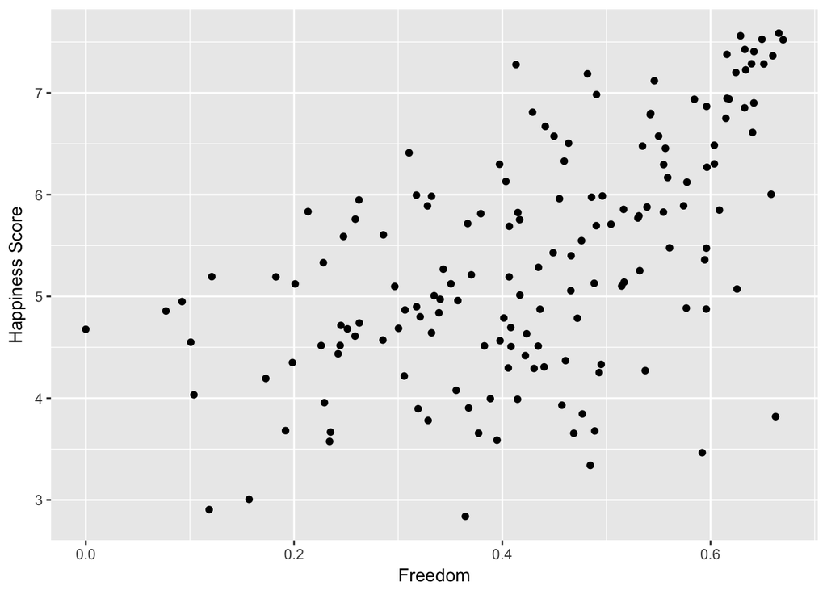

```r
library(ggplot2)
load("Happiness.RData")
hrplot <- ggplot(data=Happiness, aes(Freedom,HappinessScore)) + geom_point() + labs(x="Freedom", y="Happiness Score")

hrplot
```

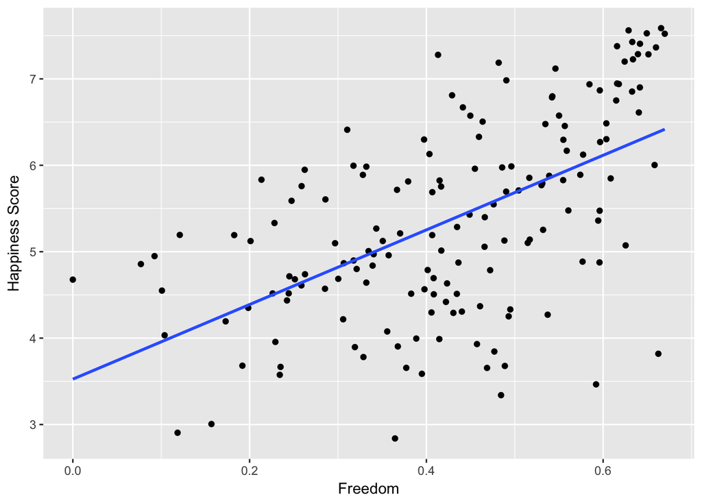

```r
hrplot + stat_smooth(method="lm", se=FALSE)
```

```r
HapReg <- lm(HappinessScore~Freedom, data=Happiness)
summary(HapReg)
```

```
##
## Call:
## lm(formula = HappinessScore ~ Freedom, data = Happiness)
##
## Residuals:
##      Min       1Q   Median       3Q      Max
## -2.61618 -0.64097  0.02194  0.82129  1.96886
##
## Coefficients:
##             Estimate Std. Error t value Pr(>|t|)
## (Intercept)   3.5252     0.2274  15.505  < 2e-16 ***
## Freedom       4.3174     0.5006   8.624 6.88e-15 ***
## ---
## Signif. codes:  0 '***' 0.001 '**' 0.01 '*' 0.05 '.' 0.1 ' ' 1
##
## Residual standard error: 0.9452 on 156 degrees of freedom
## Multiple R-squared:  0.3229, Adjusted R-squared:  0.3185
## F-statistic: 74.38 on 1 and 156 DF,  p-value: 6.876e-15
```

3. An interpretation in context of both the slope and the intercept.

After doing a linear regression on the plot it was visible to see that the slope of this scatterplot is positive. Generally as the Freedom of a country increased the Happiness score in that country increased. There were some outliers that don’t follow this trend but still don’t affect the line.

The slope is 4.3174 which means that in order to get a Freedom score of one so in other words for every .1 Freedom score is .43 to be with the scale in our plot.

The intercept is 3.5252. So when the country has basically around 0 Freedom rating the score of Happiness is 3.5 which is not drastically low compared to the freedom rating.

```r
confint(HapReg, level=0.95)
```

```
##                2.5 %   97.5 %
## (Intercept) 3.076111 3.974318
## Freedom     3.328608 5.306274
```

5. A formal hypothesis.

From our line through our plot we can hypothesize that Happiness is dependent on the amount of Freedom given to the country.

6. A formal conclusion in both Statistics and such that my Grandmother could understand.

As the Freeedom of a country increases the Happiness of the Country Increases.